# Untitled

Doynikov A.N.

2022-04-15

Читаем RUB/USD данные из файла

```r
rubusd <- read.table("RUB.csv",header = T,sep=",")
head(rubusd)
```

```
##    X.DATE.  RUBUSD
## 1 01/11/22 75.1315
## 2 01/12/22 74.8355
## 3 01/13/22 74.5277
## 4 01/14/22 74.5686
## 5 01/15/22 75.7668
## 6 01/18/22 76.0404
```

```r
dim(rubusd)
```

```
## [1] 67  2
```

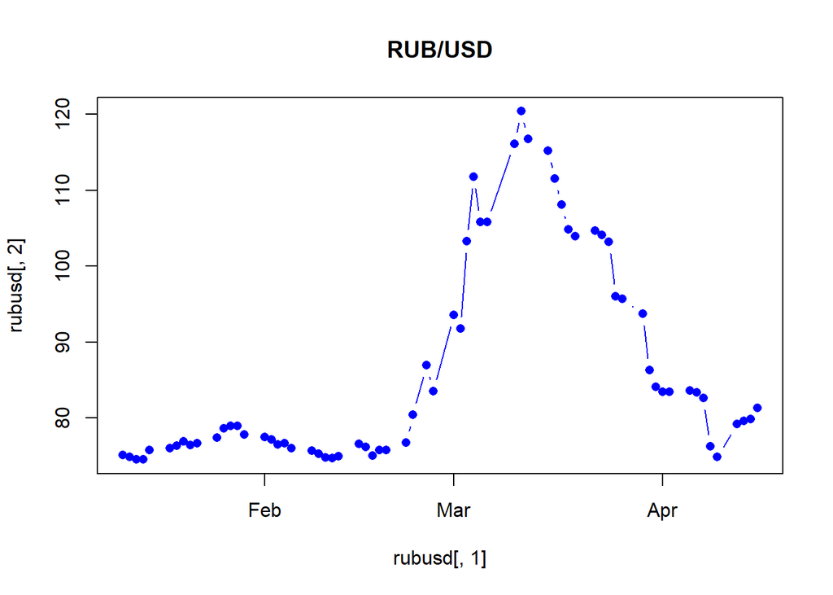

```r
rubusd[,1] <- as.Date(rubusd[,1],tryFormats = c("%Y-%m-%d", "%m/%d/%y"),optional=T)
matplot(rubusd[,1],rubusd[,2],type='b',col = 'blue',pch=16,main = 'RUB/USD')
```

RUB/USD данные содержат мощный рост после начала спецоперации в Украине.

## Операция в Украине

Взрывной рост курса случился 2022-02-25. Эту дату отметим как момент интервенции.

```r
Intervention.Time <- as.Date("2022-02-25")
 (iT <- which(rubusd[,1]== Intervention.Time))
```

```
## [1] 33
```

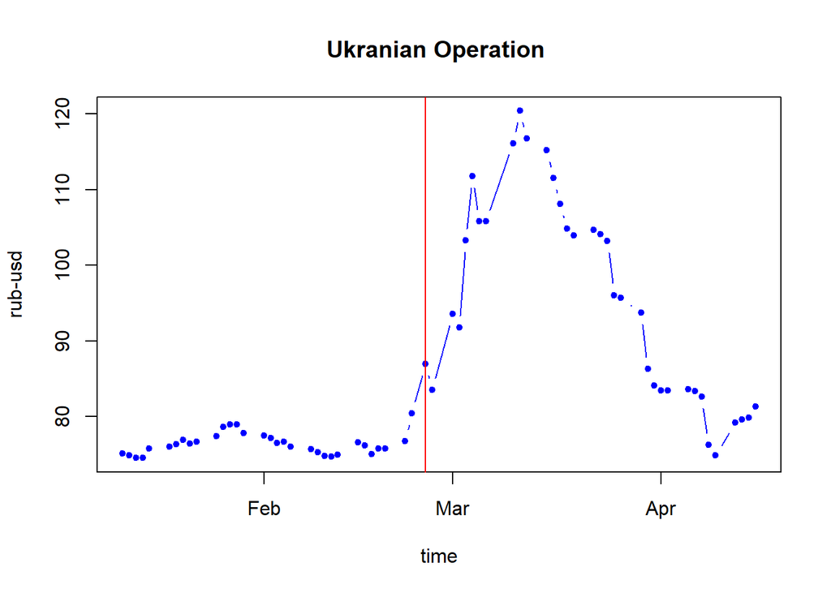

```r
matplot(rubusd[,1],rubusd[,2],type='b',main='Ukranian Operation ',col = "blue",pch = 20,xlab="time",ylab="rub-usd")
abline(v = Intervention.Time,col = "red",lwd = 1)
text(x = Intervention.Time+40,y = 300,labels = as.character(Intervention.Time),col = "red")
```

Идентифицируем ARMA модель к данным до спецоперации непосредственно перед моментом интервенции и оценим предложенную модель.

В качестве модели передаточной функции возьмем следующую модель

$$m_t=
u_0S_t(T)+\frac{\omega_0+\omega_1B+...\omega_pB^p}{1-r_1B-...-r_qB^q}S_t(T)$$
где $S_t(T)$ - функция типа ступень. Момент интервенции $T$, т.e. $S_t(T)=0,t< T$ и $S_t(T)=1$ иначе.

Идентифицируем ARMA модель непосредственно перед интервенцией

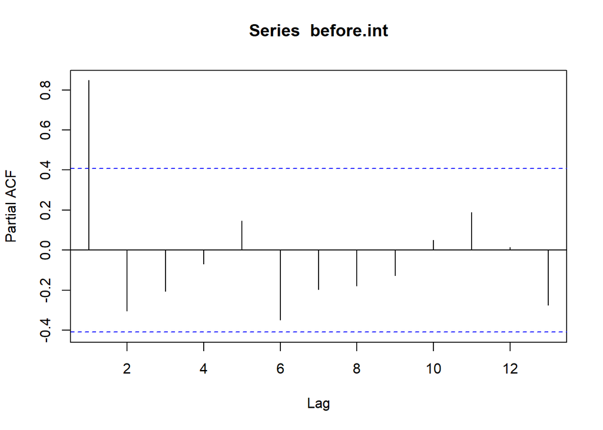

```r
before.int = rubusd[1:(iT-10),2]
pacf(before.int)
```

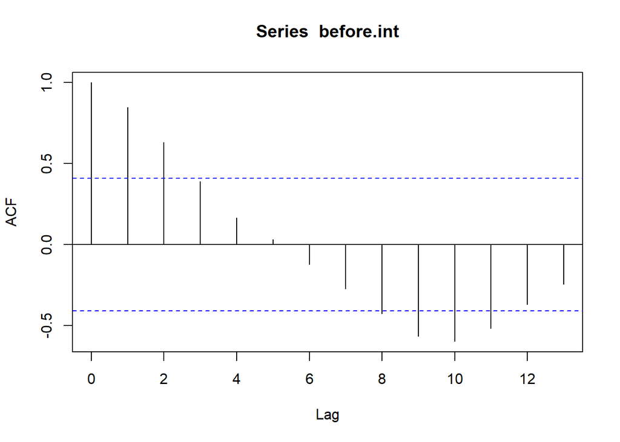

```r
acf(before.int)
```

Пусть это будет AR порядка 1 и MA порядка 0.

Оценим параметры передаточной функции, в которой порядок типа AR равен 3 и порядок типа MA равен 3.

```r
p<-3
q<-3
```

Функция для моделирования модели интервенции вида
$$m_t=
u_0S_t(T)+\frac{\omega_0+\omega_1B+...\omega_7B^q}{1-r_1B-...-r_pB^p}S_t(T)$$

```r
inter.sim <- function(n,u,ar,ma,iT,isPulse)
{
  p <- length(ar)
  q <- length(ma)
  vec <-1:n
  if (isPulse)
    interven=1*(seq(vec)==iT)
  else
    interven=1*(seq(vec)>=iT)

  inter <-stats::filter(interven,filter=ar,
                        method='recursive', side=1)*  ma[1]
  for (i in 2:q)
  {
    if (isPulse)
      interven.i <- 1*(seq(vec)==(iT+i-1))
    else
      interven.i <- 1*(seq(vec)>=(iT+i-1))

    inter.i <-stats::filter(interven.i,filter=ar,
                            method='recursive', side=1)*  ma[i]
    inter <- inter+inter.i
  }
  return (inter+u*interven)
}
```

Функция для вычисления суммы квадратов остатков
$$RSS = \sum_{i=1}^T(x_t-m_t)^2$$

```r
fn <- function(param,x,pp,qq,int.time,isPulse)
{
  nParam<- length(param)
  u0 <- param[1]
  ar <- param[2:(pp+1)]
  ma <- param[(2+pp):nParam]
  n <- length(x)
  m <- mean(x[1:(int.time-1)])
  interven <- inter.sim(n,u0,ar,ma,int.time,isPulse )+m
  res <-sum((x - interven)^2)
  return (res)
}
```

Функция для минимизации $RSS$ по параметрам $u_0,\omega_0,\omega_1, ...\omega_q,r_1,...,r_p$ модели интервенции

```r
estimate.interven<- function(x,transfer,int.time,isPulse)
{
  pp<- transfer[1]
  qq<- transfer[2]
  t.order <- pp+qq+2
  param <- rep(0.2,t.order)
  res <- optim(param,fn,gr=NULL,x=x,pp = pp,qq ==qq,int.time= int.time, isPulse=isPulse, method="BFGS")
  listres <- list(u=res$par[1],ar = res$par[2:(pp+1)],ma   =res$par[(2+pp):t.order])
  return (listres)
}
```

Оценим параметры модели для модели интервенции типа ступень

```r
isPulse<-FALSE
res<-estimate.interven(rubusd[,2],c(p,q),iT,isPulse)
```

Посмотрим на результаты оценки параметров

параметр $u_0$

```r
(u0<-res$u)
```

```
## [1] 17.85826
```

```r
(ar<-res$ar)
```

```
## [1]  1.34898054  0.09966386 -0.48532041
```

Параметры передаточноей функции типа скользящего среднего $\omega_0,\omega_1,...,\omega_3$e

```r
(ma<-res$ma)
```

```
## [1]  -7.803040   6.170461  18.626124 -17.207683
```

!!!Внимание !!! Важно проверить стационарность оцененной модели передаточной функции. Это определяется AR частью модели. Здесь воспользуемся стандартной процедурой вычисления корней характеристического полинома и проверкой, что по модулю они превосходят 1.

```r
AR.polynom <- c(1,-ar)
root<-polyroot(AR.polynom) # solve the polynomial equation
(rmin <-min(abs(root)))
```

```
## [1] 1.049667
```

```r
if (rmin<=1)
{
  print('!!!WARNING. AR part of the trunsfer function is not stationary')
  print('May be problems in prediction' )
}
```

Определим уровень курса рубля до начала операции.

```r
(intervention.level <- mean(rubusd[as.integer(iT/2):(iT-1),2]))
```

```
## [1] 76.22005
```

Смоделируем оцененную модель интервенции

```r
nn = 70
interven <- inter.sim(nn,u0,ar,ma,iT,isPulse )
```

Посмотрим на графике модель и оригинальные данные

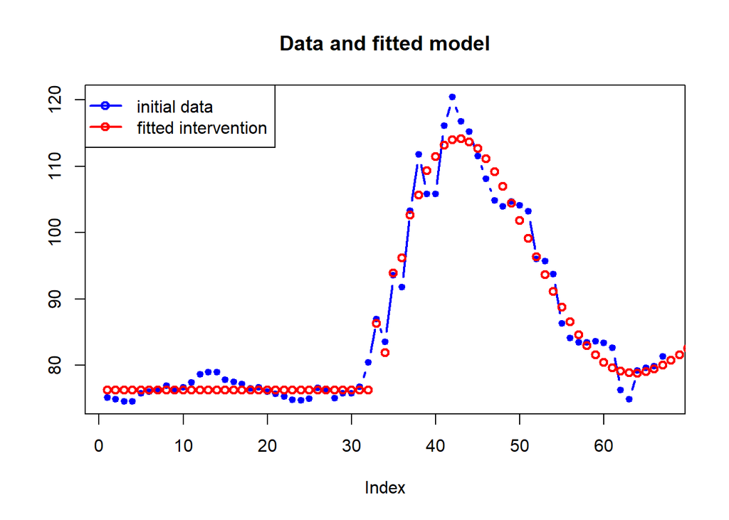

```r
plot(rubusd[,2],type= 'b',pch=20,ylab='',col= "blue",lwd =2,main = "Data and fitted model")
points(interven+intervention.level,pch = 21,col= "red",lwd =2)
legend("topleft",c("initial data","fitted intervention"),pch = 21,col = c("blue","red"),lwd =2)
```

### Эффект интервенции

Нарисуем полученную модель $m_t$.

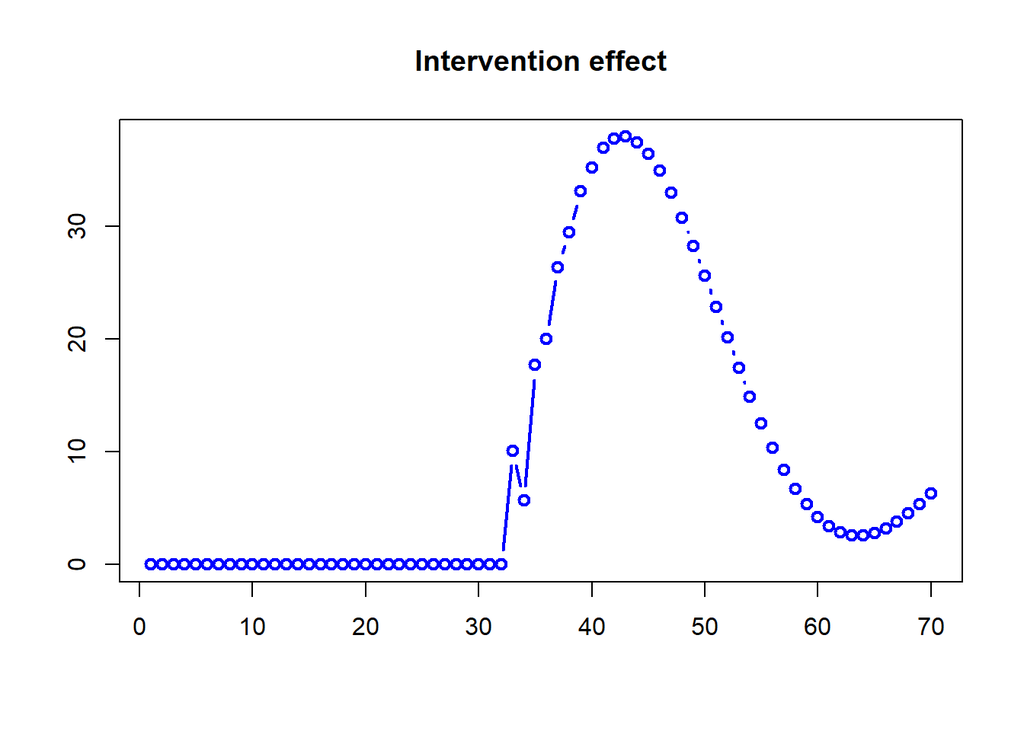

```r
matplot(interven,ylab='',main ='Intervention effect',
        type='b',pch = 21,col = c("blue"),lwd = 2)
```

Уберем эффект интервенции в оригинальных данных

```r
interven.deleted<-rubusd[,2] - interven
```

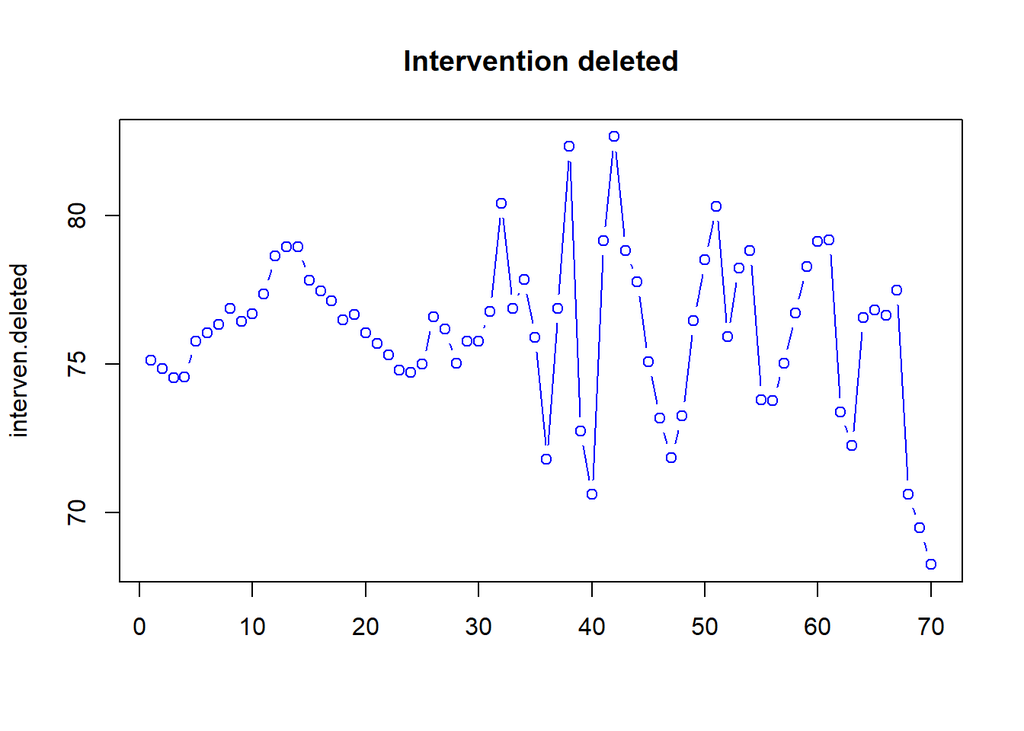

```r
matplot(interven.deleted,type = "b",pch = 21,col="blue",main = "Intervention deleted")
```